# Risk Factor Analysis

## Outcome Variable

**Outcome Variable:** ever_sstunted

## Predictor Variables

**Intervention Variable:** fage

**Adjustment Set:**

- arm
- W_mage
- meducyrs
- feducyrs
- W_mhtcm
- W_mwtkg
- W_mbmi
- W_fhtcm
- single
- brthmon
- delta_W_mage
- delta_meducyrs
- delta_feducyrs
- delta_W_mhtcm
- delta_W_mwtkg
- delta_W_mbmi
- delta_W_fhtcm
- delta_single
- delta_brthmon

## Stratifying Variables

The analysis was stratified on these variable(s):

- agecat
- studyid
- country

## Data Summary

| agecat | studyid | country | fage | ever_sstunted | n_cell | n |
| --- | --- | --- | --- | --- | --- | --- |
| 0-24 months | COHORTS | GUATEMALA | >=38 | 0 | 217 | 1301 |
| 0-24 months | COHORTS | GUATEMALA | >=38 | 1 | 169 | 1301 |
| 0-24 months | COHORTS | GUATEMALA | <32 | 0 | 329 | 1301 |
| 0-24 months | COHORTS | GUATEMALA | <32 | 1 | 280 | 1301 |
| 0-24 months | COHORTS | GUATEMALA | [32-38) | 0 | 150 | 1301 |
| 0-24 months | COHORTS | GUATEMALA | [32-38) | 1 | 156 | 1301 |
| 0-24 months | COHORTS | PHILIPPINES | >=38 | 0 | 177 | 2951 |
| 0-24 months | COHORTS | PHILIPPINES | >=38 | 1 | 153 | 2951 |
| 0-24 months | COHORTS | PHILIPPINES | <32 | 0 | 1365 | 2951 |
| 0-24 months | COHORTS | PHILIPPINES | <32 | 1 | 718 | 2951 |
| 0-24 months | COHORTS | PHILIPPINES | [32-38) | 0 | 346 | 2951 |
| 0-24 months | COHORTS | PHILIPPINES | [32-38) | 1 | 192 | 2951 |
| 0-24 months | LCNI-5 | MALAWI | >=38 | 0 | 23 | 106 |
| 0-24 months | LCNI-5 | MALAWI | >=38 | 1 | 3 | 106 |
| 0-24 months | LCNI-5 | MALAWI | <32 | 0 | 42 | 106 |
| 0-24 months | LCNI-5 | MALAWI | <32 | 1 | 14 | 106 |
| 0-24 months | LCNI-5 | MALAWI | [32-38) | 0 | 15 | 106 |
| 0-24 months | LCNI-5 | MALAWI | [32-38) | 1 | 9 | 106 |
| 0-24 months | MAL-ED | BANGLADESH | >=38 | 0 | 53 | 151 |
| 0-24 months | MAL-ED | BANGLADESH | >=38 | 1 | 16 | 151 |
| 0-24 months | MAL-ED | BANGLADESH | <32 | 0 | 21 | 151 |
| 0-24 months | MAL-ED | BANGLADESH | <32 | 1 | 9 | 151 |
| 0-24 months | MAL-ED | BANGLADESH | [32-38) | 0 | 41 | 151 |
| 0-24 months | MAL-ED | BANGLADESH | [32-38) | 1 | 11 | 151 |
| 0-24 months | MAL-ED | BRAZIL | >=38 | 0 | 27 | 79 |
| 0-24 months | MAL-ED | BRAZIL | >=38 | 1 | 3 | 79 |
| 0-24 months | MAL-ED | BRAZIL | <32 | 0 | 14 | 79 |
| 0-24 months | MAL-ED | BRAZIL | <32 | 1 | 4 | 79 |
| 0-24 months | MAL-ED | BRAZIL | [32-38) | 0 | 29 | 79 |
| 0-24 months | MAL-ED | BRAZIL | [32-38) | 1 | 2 | 79 |

[output cut: 126 more lines]

The following strata were considered:

- agecat: 0-24 months, studyid: COHORTS, country: GUATEMALA
- agecat: 0-24 months, studyid: COHORTS, country: PHILIPPINES
- agecat: 0-24 months, studyid: LCNI-5, country: MALAWI
- agecat: 0-24 months, studyid: MAL-ED, country: BANGLADESH
- agecat: 0-24 months, studyid: MAL-ED, country: BRAZIL
- agecat: 0-24 months, studyid: MAL-ED, country: INDIA
- agecat: 0-24 months, studyid: MAL-ED, country: NEPAL
- agecat: 0-24 months, studyid: MAL-ED, country: PERU
- agecat: 0-24 months, studyid: MAL-ED, country: SOUTH AFRICA
- agecat: 0-24 months, studyid: MAL-ED, country: TANZANIA, UNITED REPUBLIC OF
- agecat: 0-24 months, studyid: PROBIT, country: BELARUS
- agecat: 0-24 months, studyid: SAS-CompFeed, country: INDIA
- agecat: 0-24 months, studyid: SAS-FoodSuppl, country: INDIA
- agecat: 0-6 months, studyid: COHORTS, country: GUATEMALA
- agecat: 0-6 months, studyid: COHORTS, country: PHILIPPINES
- agecat: 0-6 months, studyid: LCNI-5, country: MALAWI
- agecat: 0-6 months, studyid: MAL-ED, country: BANGLADESH
- agecat: 0-6 months, studyid: MAL-ED, country: BRAZIL
- agecat: 0-6 months, studyid: MAL-ED, country: INDIA
- agecat: 0-6 months, studyid: MAL-ED, country: NEPAL
- agecat: 0-6 months, studyid: MAL-ED, country: PERU
- agecat: 0-6 months, studyid: MAL-ED, country: SOUTH AFRICA
- agecat: 0-6 months, studyid: MAL-ED, country: TANZANIA, UNITED REPUBLIC OF
- agecat: 0-6 months, studyid: PROBIT, country: BELARUS
- agecat: 0-6 months, studyid: SAS-CompFeed, country: INDIA
- agecat: 0-6 months, studyid: SAS-FoodSuppl, country: INDIA

### Dropped Strata

Some strata were dropped due to rare outcomes:

- agecat: 0-24 months, studyid: LCNI-5, country: MALAWI
- agecat: 0-24 months, studyid: MAL-ED, country: BRAZIL
- agecat: 0-24 months, studyid: MAL-ED, country: NEPAL
- agecat: 0-24 months, studyid: MAL-ED, country: PERU
- agecat: 0-24 months, studyid: MAL-ED, country: SOUTH AFRICA
- agecat: 0-24 months, studyid: MAL-ED, country: TANZANIA, UNITED REPUBLIC OF
- agecat: 0-6 months, studyid: LCNI-5, country: MALAWI
- agecat: 0-6 months, studyid: MAL-ED, country: BANGLADESH
- agecat: 0-6 months, studyid: MAL-ED, country: BRAZIL
- agecat: 0-6 months, studyid: MAL-ED, country: INDIA
- agecat: 0-6 months, studyid: MAL-ED, country: NEPAL
- agecat: 0-6 months, studyid: MAL-ED, country: PERU
- agecat: 0-6 months, studyid: MAL-ED, country: SOUTH AFRICA
- agecat: 0-6 months, studyid: MAL-ED, country: TANZANIA, UNITED REPUBLIC OF

## Methods Detail

We’re interested in the causal parameters $E[Y_a]$ for all values of $a \in \mathcal{A}$. These parameters represent the mean outcome if, possibly contrary to fact, we intervened to set all units to have $A=a$. Under the randomization and positivity assumptions, these are identified by the statistical parameters $\psi_a=E_W[E_{Y|A,W}(Y|A=a,W)]$. In addition, we’re interested in the mean of $Y$, $E[Y]$ under no intervention (the observed mean). We will estimate these parameters by using SuperLearner to fit the relevant likelihood factors – $E_{Y|A,W}(Y|A=a,W)$ and $p(A=a|W)$, and then updating our likelihood fit using a joint TMLE.

For unadjusted analyses ($W=\{\}$), initial likelihoods were estimated using Lrnr_glm to estimate the simple $E(Y|A)$ and Lrnr_mean to estimate $p(A)$. For adjusted analyses, a small library containing Lrnr_glmnet, Lrnr_xgboost, and Lrnr_mean was used.

Having estimated these parameters, we will then use the delta method to estimate relative risks and attributable risks relative to a prespecified baseline level of $A$.

# Results Detail

## Results Plots

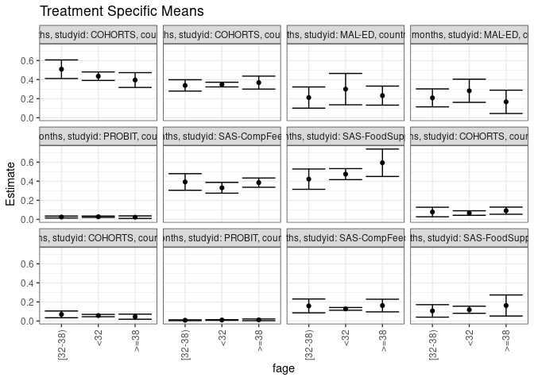

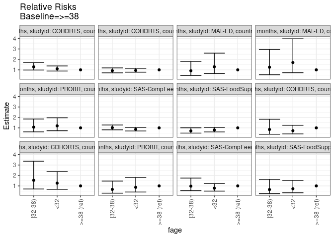

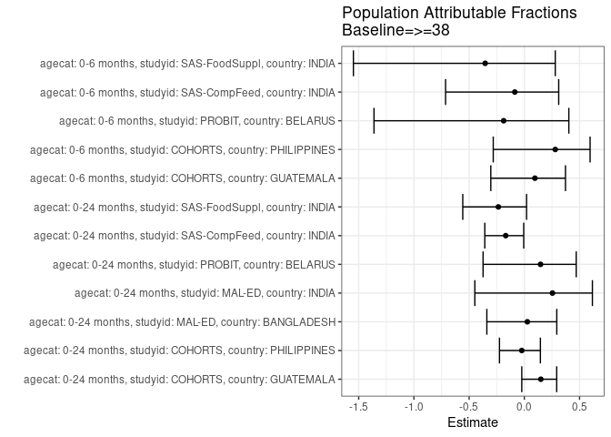

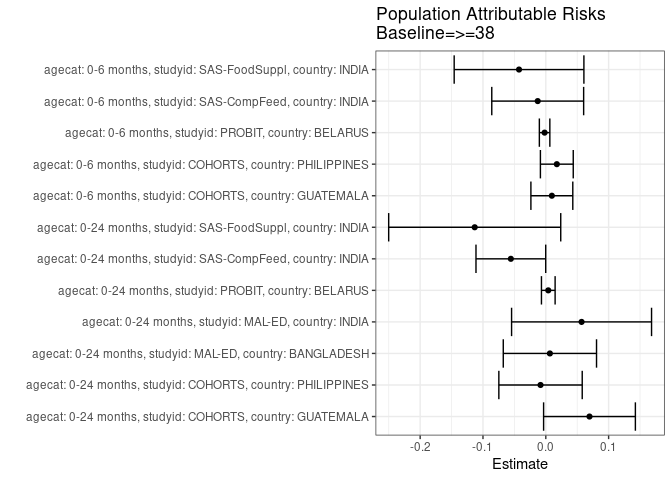

## Results Table

### Parameter: TSM

| agecat | studyid | country | intervention_level | baseline_level | estimate | ci_lower | ci_upper |
| --- | --- | --- | --- | --- | --- | --- | --- |
| 0-24 months | COHORTS | GUATEMALA | >=38 | NA | 0.3954736 | 0.3177174 | 0.4732298 |
| 0-24 months | COHORTS | GUATEMALA | <32 | NA | 0.4358122 | 0.3910537 | 0.4805706 |
| 0-24 months | COHORTS | GUATEMALA | [32-38) | NA | 0.5091910 | 0.4114867 | 0.6068953 |
| 0-24 months | COHORTS | PHILIPPINES | >=38 | NA | 0.3685978 | 0.3004736 | 0.4367219 |
| 0-24 months | COHORTS | PHILIPPINES | <32 | NA | 0.3477612 | 0.3231273 | 0.3723950 |
| 0-24 months | COHORTS | PHILIPPINES | [32-38) | NA | 0.3389353 | 0.2792924 | 0.3985783 |
| 0-24 months | MAL-ED | BANGLADESH | >=38 | NA | 0.2318841 | 0.1319726 | 0.3317955 |
| 0-24 months | MAL-ED | BANGLADESH | <32 | NA | 0.3000000 | 0.1354719 | 0.4645281 |
| 0-24 months | MAL-ED | BANGLADESH | [32-38) | NA | 0.2115385 | 0.1001669 | 0.3229100 |
| 0-24 months | MAL-ED | INDIA | >=38 | NA | 0.1666667 | 0.0445476 | 0.2887858 |
| 0-24 months | MAL-ED | INDIA | <32 | NA | 0.2830189 | 0.1613654 | 0.4046724 |
| 0-24 months | MAL-ED | INDIA | [32-38) | NA | 0.2083333 | 0.1142343 | 0.3024324 |
| 0-24 months | PROBIT | BELARUS | >=38 | NA | 0.0230176 | 0.0097610 | 0.0362742 |
| 0-24 months | PROBIT | BELARUS | <32 | NA | 0.0274899 | 0.0203566 | 0.0346233 |
| 0-24 months | PROBIT | BELARUS | [32-38) | NA | 0.0245977 | 0.0146580 | 0.0345374 |
| 0-24 months | SAS-CompFeed | INDIA | >=38 | NA | 0.3856990 | 0.3371788 | 0.4342192 |
| 0-24 months | SAS-CompFeed | INDIA | <32 | NA | 0.3313506 | 0.2747603 | 0.3879408 |
| 0-24 months | SAS-CompFeed | INDIA | [32-38) | NA | 0.3925485 | 0.3055494 | 0.4795476 |
| 0-24 months | SAS-FoodSuppl | INDIA | >=38 | NA | 0.5940340 | 0.4500057 | 0.7380622 |
| 0-24 months | SAS-FoodSuppl | INDIA | <32 | NA | 0.4747510 | 0.4169175 | 0.5325844 |
| 0-24 months | SAS-FoodSuppl | INDIA | [32-38) | NA | 0.4220221 | 0.3153683 | 0.5286760 |
| 0-6 months | COHORTS | GUATEMALA | >=38 | NA | 0.0911356 | 0.0538007 | 0.1284706 |
| 0-6 months | COHORTS | GUATEMALA | <32 | NA | 0.0660579 | 0.0423942 | 0.0897217 |
| 0-6 months | COHORTS | GUATEMALA | [32-38) | NA | 0.0771533 | 0.0270688 | 0.1272378 |
| 0-6 months | COHORTS | PHILIPPINES | >=38 | NA | 0.0451338 | 0.0183607 | 0.0719068 |
| 0-6 months | COHORTS | PHILIPPINES | <32 | NA | 0.0570527 | 0.0448870 | 0.0692184 |
| 0-6 months | COHORTS | PHILIPPINES | [32-38) | NA | 0.0694629 | 0.0339303 | 0.1049955 |
| 0-6 months | PROBIT | BELARUS | >=38 | NA | 0.0121131 | 0.0029383 | 0.0212879 |
| 0-6 months | PROBIT | BELARUS | <32 | NA | 0.0104941 | 0.0072135 | 0.0137747 |
| 0-6 months | PROBIT | BELARUS | [32-38) | NA | 0.0080841 | 0.0035338 | 0.0126344 |
| 0-6 months | SAS-CompFeed | INDIA | >=38 | NA | 0.1621943 | 0.0956924 | 0.2286962 |
| 0-6 months | SAS-CompFeed | INDIA | <32 | NA | 0.1272389 | 0.1129868 | 0.1414910 |
| 0-6 months | SAS-CompFeed | INDIA | [32-38) | NA | 0.1583751 | 0.0856468 | 0.2311033 |
| 0-6 months | SAS-FoodSuppl | INDIA | >=38 | NA | 0.1627907 | 0.0523146 | 0.2732668 |
| 0-6 months | SAS-FoodSuppl | INDIA | <32 | NA | 0.1180556 | 0.0807444 | 0.1553667 |
| 0-6 months | SAS-FoodSuppl | INDIA | [32-38) | NA | 0.1058824 | 0.0403930 | 0.1713717 |

### Parameter: E(Y)

| agecat | studyid | country | intervention_level | baseline_level | estimate | ci_lower | ci_upper |
| --- | --- | --- | --- | --- | --- | --- | --- |
| 0-24 months | COHORTS | GUATEMALA | NA | NA | 0.4650269 | 0.4379137 | 0.4921401 |
| 0-24 months | COHORTS | PHILIPPINES | NA | NA | 0.3602169 | 0.3428934 | 0.3775404 |
| 0-24 months | MAL-ED | BANGLADESH | NA | NA | 0.2384106 | 0.1702198 | 0.3066014 |
| 0-24 months | MAL-ED | INDIA | NA | NA | 0.2236025 | 0.1590417 | 0.2881632 |
| 0-24 months | PROBIT | BELARUS | NA | NA | 0.0269706 | 0.0196621 | 0.0342790 |
| 0-24 months | SAS-CompFeed | INDIA | NA | NA | 0.3300654 | 0.3020915 | 0.3580392 |
| 0-24 months | SAS-FoodSuppl | INDIA | NA | NA | 0.4808612 | 0.4329065 | 0.5288160 |
| 0-6 months | COHORTS | GUATEMALA | NA | NA | 0.1007605 | 0.0825622 | 0.1189587 |
| 0-6 months | COHORTS | PHILIPPINES | NA | NA | 0.0626906 | 0.0539432 | 0.0714380 |
| 0-6 months | PROBIT | BELARUS | NA | NA | 0.0102016 | 0.0069540 | 0.0134492 |
| 0-6 months | SAS-CompFeed | INDIA | NA | NA | 0.1493124 | 0.1303783 | 0.1682465 |
| 0-6 months | SAS-FoodSuppl | INDIA | NA | NA | 0.1201923 | 0.0889059 | 0.1514788 |

### Parameter: RR

| agecat | studyid | country | intervention_level | baseline_level | estimate | ci_lower | ci_upper |
| --- | --- | --- | --- | --- | --- | --- | --- |
| 0-24 months | COHORTS | GUATEMALA | >=38 | >=38 | 1.0000000 | 1.0000000 | 1.000000 |
| 0-24 months | COHORTS | GUATEMALA | <32 | >=38 | 1.1020008 | 0.8837710 | 1.374118 |
| 0-24 months | COHORTS | GUATEMALA | [32-38) | >=38 | 1.2875475 | 0.9793602 | 1.692716 |
| 0-24 months | COHORTS | PHILIPPINES | >=38 | >=38 | 1.0000000 | 1.0000000 | 1.000000 |
| 0-24 months | COHORTS | PHILIPPINES | <32 | >=38 | 0.9434707 | 0.7746647 | 1.149061 |
| 0-24 months | COHORTS | PHILIPPINES | [32-38) | >=38 | 0.9195263 | 0.7129412 | 1.185972 |
| 0-24 months | MAL-ED | BANGLADESH | >=38 | >=38 | 1.0000000 | 1.0000000 | 1.000000 |
| 0-24 months | MAL-ED | BANGLADESH | <32 | >=38 | 1.2937500 | 0.6441055 | 2.598625 |
| 0-24 months | MAL-ED | BANGLADESH | [32-38) | >=38 | 0.9122596 | 0.4620194 | 1.801261 |
| 0-24 months | MAL-ED | INDIA | >=38 | >=38 | 1.0000000 | 1.0000000 | 1.000000 |
| 0-24 months | MAL-ED | INDIA | <32 | >=38 | 1.6981132 | 0.7261684 | 3.970964 |
| 0-24 months | MAL-ED | INDIA | [32-38) | >=38 | 1.2500000 | 0.5285589 | 2.956151 |
| 0-24 months | PROBIT | BELARUS | >=38 | >=38 | 1.0000000 | 1.0000000 | 1.000000 |
| 0-24 months | PROBIT | BELARUS | <32 | >=38 | 1.1943012 | 0.7254677 | 1.966118 |
| 0-24 months | PROBIT | BELARUS | [32-38) | >=38 | 1.0686472 | 0.6178973 | 1.848215 |
| 0-24 months | SAS-CompFeed | INDIA | >=38 | >=38 | 1.0000000 | 1.0000000 | 1.000000 |
| 0-24 months | SAS-CompFeed | INDIA | <32 | >=38 | 0.8590911 | 0.7026747 | 1.050326 |
| 0-24 months | SAS-CompFeed | INDIA | [32-38) | >=38 | 1.0177586 | 0.8120723 | 1.275542 |
| 0-24 months | SAS-FoodSuppl | INDIA | >=38 | >=38 | 1.0000000 | 1.0000000 | 1.000000 |
| 0-24 months | SAS-FoodSuppl | INDIA | <32 | >=38 | 0.7991984 | 0.6098298 | 1.047371 |
| 0-24 months | SAS-FoodSuppl | INDIA | [32-38) | >=38 | 0.7104343 | 0.5006791 | 1.008065 |
| 0-6 months | COHORTS | GUATEMALA | >=38 | >=38 | 1.0000000 | 1.0000000 | 1.000000 |
| 0-6 months | COHORTS | GUATEMALA | <32 | >=38 | 0.7248309 | 0.4200561 | 1.250737 |
| 0-6 months | COHORTS | GUATEMALA | [32-38) | >=38 | 0.8465767 | 0.3926026 | 1.825490 |
| 0-6 months | COHORTS | PHILIPPINES | >=38 | >=38 | 1.0000000 | 1.0000000 | 1.000000 |
| 0-6 months | COHORTS | PHILIPPINES | <32 | >=38 | 1.2640796 | 0.6734657 | 2.372648 |
| 0-6 months | COHORTS | PHILIPPINES | [32-38) | >=38 | 1.5390449 | 0.7041402 | 3.363903 |
| 0-6 months | PROBIT | BELARUS | >=38 | >=38 | 1.0000000 | 1.0000000 | 1.000000 |
| 0-6 months | PROBIT | BELARUS | <32 | >=38 | 0.8663432 | 0.4149040 | 1.808974 |
| 0-6 months | PROBIT | BELARUS | [32-38) | >=38 | 0.6673853 | 0.3045378 | 1.462554 |
| 0-6 months | SAS-CompFeed | INDIA | >=38 | >=38 | 1.0000000 | 1.0000000 | 1.000000 |
| 0-6 months | SAS-CompFeed | INDIA | <32 | >=38 | 0.7844842 | 0.5013294 | 1.227567 |
| 0-6 months | SAS-CompFeed | INDIA | [32-38) | >=38 | 0.9764525 | 0.5455267 | 1.747778 |
| 0-6 months | SAS-FoodSuppl | INDIA | >=38 | >=38 | 1.0000000 | 1.0000000 | 1.000000 |
| 0-6 months | SAS-FoodSuppl | INDIA | <32 | >=38 | 0.7251984 | 0.3430315 | 1.533133 |
| 0-6 months | SAS-FoodSuppl | INDIA | [32-38) | >=38 | 0.6504202 | 0.2596698 | 1.629171 |

### Parameter: PAR

| agecat | studyid | country | intervention_level | baseline_level | estimate | ci_lower | ci_upper |
| --- | --- | --- | --- | --- | --- | --- | --- |
| 0-24 months | COHORTS | GUATEMALA | >=38 | NA | 0.0695533 | -0.0034972 | 0.1426038 |
| 0-24 months | COHORTS | PHILIPPINES | >=38 | NA | -0.0083809 | -0.0747451 | 0.0579833 |
| 0-24 months | MAL-ED | BANGLADESH | >=38 | NA | 0.0065265 | -0.0676987 | 0.0807518 |
| 0-24 months | MAL-ED | INDIA | >=38 | NA | 0.0569358 | -0.0544732 | 0.1683448 |
| 0-24 months | PROBIT | BELARUS | >=38 | NA | 0.0039530 | -0.0069220 | 0.0148280 |
| 0-24 months | SAS-CompFeed | INDIA | >=38 | NA | -0.0556337 | -0.1111385 | -0.0001289 |
| 0-24 months | SAS-FoodSuppl | INDIA | >=38 | NA | -0.1131727 | -0.2501218 | 0.0237764 |
| 0-6 months | COHORTS | GUATEMALA | >=38 | NA | 0.0096248 | -0.0237187 | 0.0429683 |
| 0-6 months | COHORTS | PHILIPPINES | >=38 | NA | 0.0175568 | -0.0085844 | 0.0436981 |
| 0-6 months | PROBIT | BELARUS | >=38 | NA | -0.0019115 | -0.0102613 | 0.0064384 |
| 0-6 months | SAS-CompFeed | INDIA | >=38 | NA | -0.0128820 | -0.0860109 | 0.0602469 |
| 0-6 months | SAS-FoodSuppl | INDIA | >=38 | NA | -0.0425984 | -0.1458489 | 0.0606521 |

### Parameter: PAF

| agecat | studyid | country | intervention_level | baseline_level | estimate | ci_lower | ci_upper |
| --- | --- | --- | --- | --- | --- | --- | --- |
| 0-24 months | COHORTS | GUATEMALA | >=38 | NA | 0.1495684 | -0.0231885 | 0.2931567 |
| 0-24 months | COHORTS | PHILIPPINES | >=38 | NA | -0.0232662 | -0.2251682 | 0.1453633 |
| 0-24 months | MAL-ED | BANGLADESH | >=38 | NA | 0.0273752 | -0.3395046 | 0.2937695 |
| 0-24 months | MAL-ED | INDIA | >=38 | NA | 0.2546296 | -0.4483342 | 0.6164028 |
| 0-24 months | PROBIT | BELARUS | >=38 | NA | 0.1465662 | -0.3736143 | 0.4697571 |
| 0-24 months | SAS-CompFeed | INDIA | >=38 | NA | -0.1685535 | -0.3579754 | -0.0055537 |
| 0-24 months | SAS-FoodSuppl | INDIA | >=38 | NA | -0.2353542 | -0.5575709 | 0.0202051 |
| 0-6 months | COHORTS | GUATEMALA | >=38 | NA | 0.0955218 | -0.3036857 | 0.3724861 |
| 0-6 months | COHORTS | PHILIPPINES | >=38 | NA | 0.2800554 | -0.2815085 | 0.5955390 |
| 0-6 months | PROBIT | BELARUS | >=38 | NA | -0.1873713 | -1.3614428 | 0.4029707 |
| 0-6 months | SAS-CompFeed | INDIA | >=38 | NA | -0.0862753 | -0.7132349 | 0.3112480 |
| 0-6 months | SAS-FoodSuppl | INDIA | >=38 | NA | -0.3544186 | -1.5480213 | 0.2800493 |